# Curso 7 Regression Models

What does the estimate for hunger$Year represent?

1: the annual decrease in percentage of hungry males 2: the annual decrease in percentage of hungry children of both genders 3: the annual decrease in percentage of hungry females

Selection: 2

That’s a job well done!

|========================================================================== | 57%

Now we’ll replot the data points along with two new lines using different colors. The red line will have the female intercept and the blue line will have the male intercept.

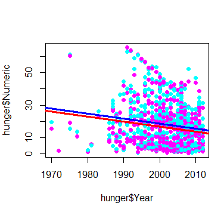

qownnotes-media-BCnmqs

|============================================================================= | 59%

The lines appear parallel. This is because

1: they have the same slope 2: I have no idea 3: they have slopes that are very close

Selection: 1

Excellent job!

|================================================================================= | 62%

Now we’ll consider the interaction between year and gender to see how that affects changes in rates of hunger. To do this we’ll add a third term to the predictor portion of our model formula, the product of year and gender.

…

|==================================================================================== | 65%

Create the model lmInter. Numeric is the outcome and the three predictors are Year, Sex, and Sex*Year. The data is “hunger”.

> lmInter <- lm(Numeric ~ Year,Sex,Sex*Year,hunger) Error in is.data.frame(data) : object ‘Sex’ not found lmBoth <- lm(Numeric ~ Year+Sex,hunger)

You seem to have misspelled the model’s name. I was expecting lmInter but you apparently typed lmBoth.

You’re close…I can feel it! Try it again. Or, type info() for more options.

Type lmInter <- lm(hunger$Numeric ~ hunger$Year + hunger$Sex + hunger$Year * hunger$Sex) or lmInter <- lm(Numeric ~ Year + Sex + Year*Sex, hunger)

> lmInter <- lm(Numeric ~ Year + Sex +Year*Sex, hunger)

Excellent work!

|======================================================================================== | 68%

Now look at the summary of lmInter with the R command summary.

> summary(lmInter)

```
Call:
lm(formula = Numeric ~ Year + Sex + Year * Sex, data = hunger)

Residuals:
    Min      1Q  Median      3Q     Max
-25.913 -11.248  -1.853   7.087  46.146

Coefficients:
              Estimate Std. Error t value Pr(>|t|)
(Intercept)  603.50580  171.05519   3.528 0.000439 ***
Year          -0.29340    0.08547  -3.433 0.000623 ***
SexMale       61.94772  241.90858   0.256 0.797946
Year:SexMale  -0.03000    0.12087  -0.248 0.804022
---
Signif. codes:  0 '***' 0.001 '**' 0.01 '*' 0.05 '.' 0.1 ' ' 1

Residual standard error: 13.21 on 944 degrees of freedom
Multiple R-squared:  0.03181,   Adjusted R-squared:  0.02874
F-statistic: 10.34 on 3 and 944 DF,  p-value: 1.064e-06
```

Excellent work!

|=========================================================================================== | 70%

What is the percentage of hungry females at year 0?

1: The model doesn’t say. 2: 61.94772 3: 603.5058

Selection: 3

Your dedication is inspiring!

|=============================================================================================== | 73%

What is the percentage of hungry males at year 0?

1: 61.94772 2: 665.4535 3: 603.5058 4: The model doesn’t say.

Selection: 2

Excellent work!

|================================================================================================== | 76%

What is the annual change in percentage of hungry females?

1: -0.03000 2: 0.08547 3: The model doesn’t say. 4: -0.29340

Selection: 4

You are amazing!

|====================================================================================================== | 78%

What is the annual change in percentage of hungry males?

1: 0.12087 2: -0.03000 3: -0.32340 4: The model doesn’t say.

Selection: 2

Not exactly. Give it another go.

The estimate associated with Year:SexMale represents the distance of the annual change in percent of males from that of females.

1: The model doesn’t say. 2: 0.12087 3: -0.03000 4: -0.32340

Selection: 4

You are quite good my friend!

|========================================================================================================= | 81%

Now we’ll replot the data points along with two new lines using different colors to distinguish between the genders.

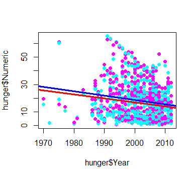

qownnotes-media-yXmRTO

|============================================================================================================= | 84%

Which line has the steeper slope?

1: Female 2: Male 3: They look about the same

Selection: 1

Not quite! Try again.

The lines are not parallel and will eventually intersect. The line that is further from horizontal (which has slope 0) has a steeper slope and indicates a faster rate of change. Which line has a slope further from 0?

1: They look about the same 2: Male 3: Female

Selection: 2

All that hard work is paying off!

|================================================================================================================ | 86%

Finally, we note that things are a little trickier when we’re dealing with an interaction between predictors which are continuous (and not factors). The slides show the underlying algebra, but we can summarize.

…

|==================================================================================================================== | 89%

Suppose we have two interacting predictors and one of them is held constant. The expected change in the outcome for a unit change in the other predictor is the coefficient of that changing predictor + the coefficient of the interaction * the value of the predictor held constant.

…

|======================================================================================================================= | 92%

Suppose the linear model is Hi = b0 + (b1*Ii) + (b2*Yi)+ (b3*Ii*Yi) + ei. Here the H’s represent the outcomes, the I’s and Y’s the predictors, neither of which is a category, and the b’s represent the estimated coefficients of the predictors. We can ignore the e’s which represent the residuals of the model. This equation models a continuous interaction since neither I nor Y is a category or factor. Suppose we fix I at some value and let Y vary.

…

|=========================================================================================================================== | 95%

Which expression represents the change in H per unit change in Y given that I is fixed at 5?

1: b0+b2 2: b2+b3*Y 3: b1+5*b3 4: b2+b3*5

Selection: 4

You are quite good my friend!

|============================================================================================================================== | 97%

Congratulations! You’ve finished this final lesson in multivariable regression models.

## Ajustes y relacción entre variables

El Ajuste es la idea de poner regresores dentro del modelo lineal e investigar el role de una tercera variable en la relación entre los otros dos, ya que es habitual el caso en el que esta tercera variable pueda causar distorsión o confusión en las otras

Como ejemplo, podemos considerar los porcentajes de cancer de pulmón y los usos de pastillas de menta. Estamos mirando el volumen expiratorio forzado y el consumo de pastillas de menta. Si encontráramos significancia estadística en la relacción de la regresión, no sería inteligente ir rápidamente a los periódicos y decir que el consumo de pastillas de menta baja la capacidad pulmonar. En primer lugar, auqnue la relacción es sólida, no se sabe si es causal. Pero más importante en este caso, la verdadera razón son los hábitos tabáquicos. Fumar está muy relaccionado con ambas cosas, capacidad pulmonar y consumo de pastillas de menta. Cómo te defiendes de la acusación de que es variabilidad en los hábitos como fumador?

Si el hallazgo apareciera entre fumadores y no fumadores de manera separada, entonces se podría tener algo. La gente no lo creería a menos que eliminásemos la constante fumador. Esta es la idea de añadir una variable de regresión como ajuste. El coeficiente de interés es interpretado como el efecto del predictor en la respuesta, manteniendo ajuste de la variable constante.

Buscar los ajustes es una tarea complicada, ya que se trata de ir haciendo pruebas y comprobando resultados, muchas veces teniendo que recurrir a un experto en el sector para que nos aconseje.

A continuación camos a ver mediante ejemplos, cómo puede influir o no un ajuste mediante la comparación de dos grupos, digamos que unos reciben tratamiento y otros no lo reciben.

**EJEMPLO 1**

Las líneas horizontales son las medias de los grupos, mientras que el resto son las regresiones lineales teniendo en cuenta los grupos y sin tenerlos en cuenta.

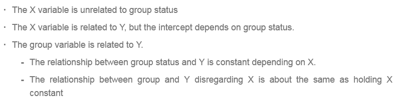

qownnotes-media-DJgAwG

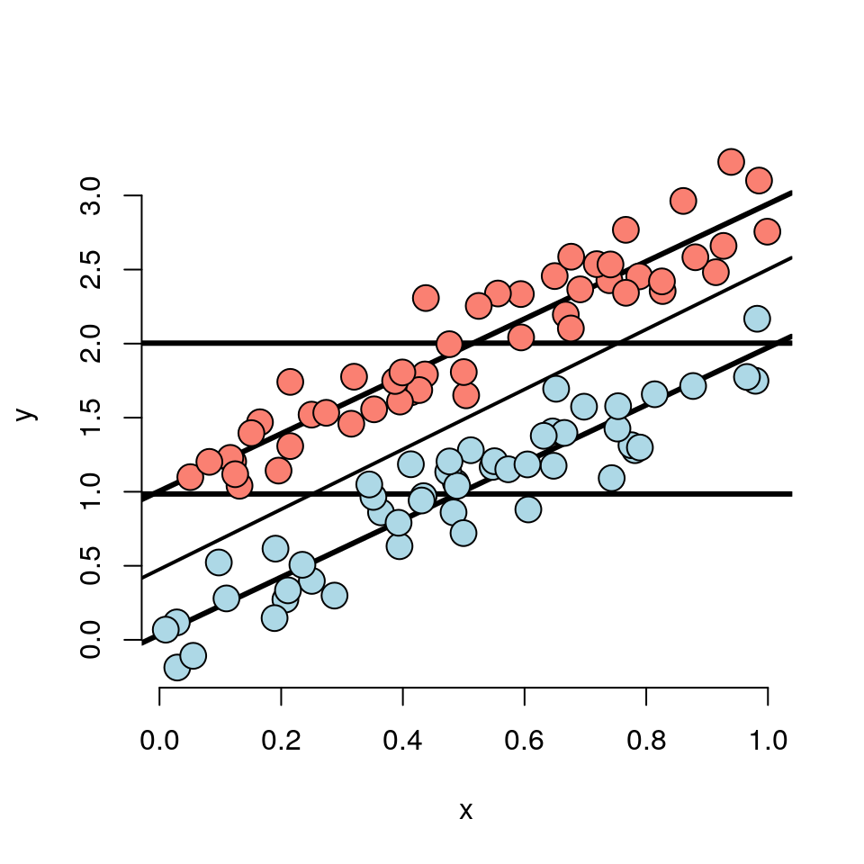

**EJEMPLO2**

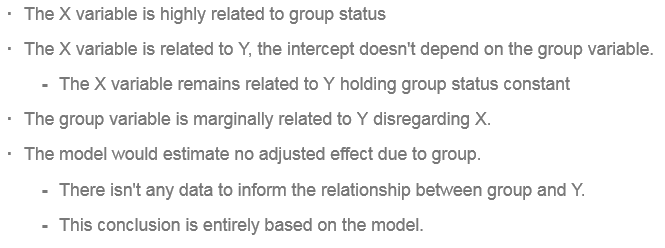

qownnotes-media-CPMPro

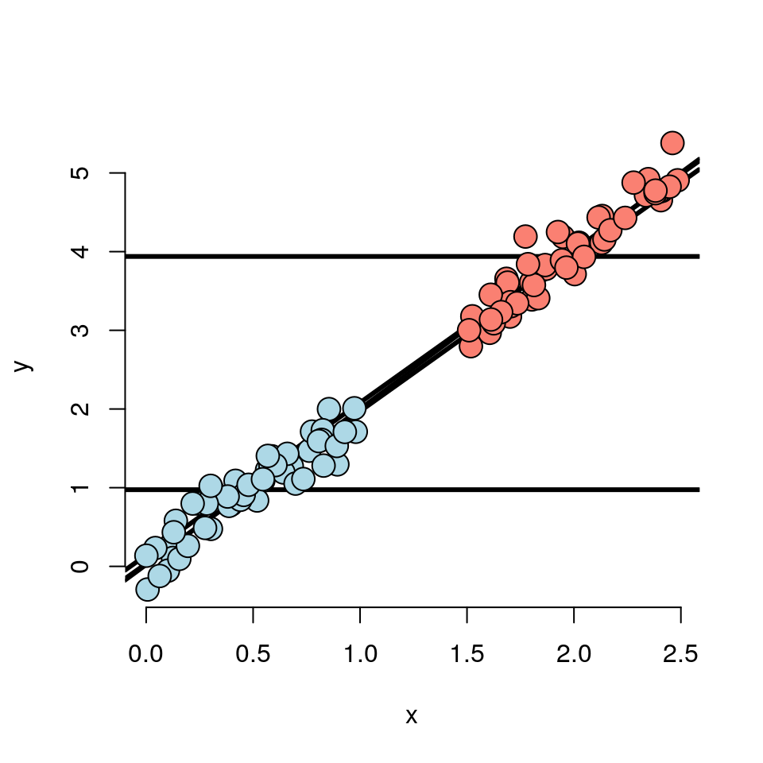

**EJEMPLO 3**

La asociación marginal es la diferencia entre las medias

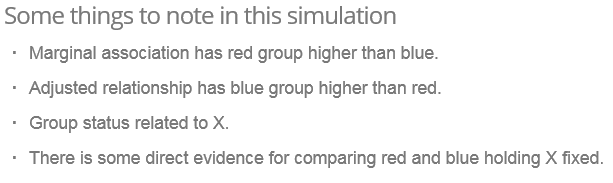

qownnotes-media-mkldqL

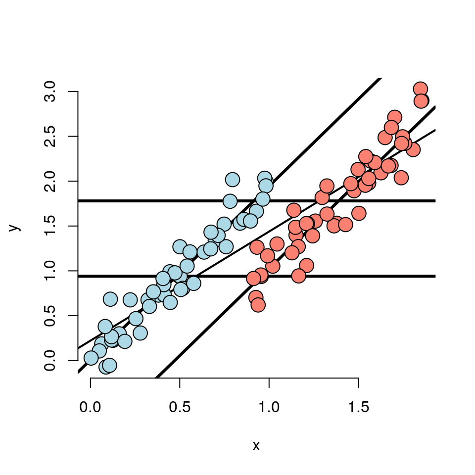

**EJEMPLO 4**

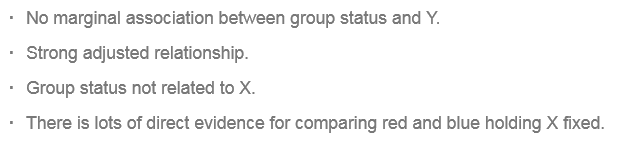

qownnotes-media-Tjioqp

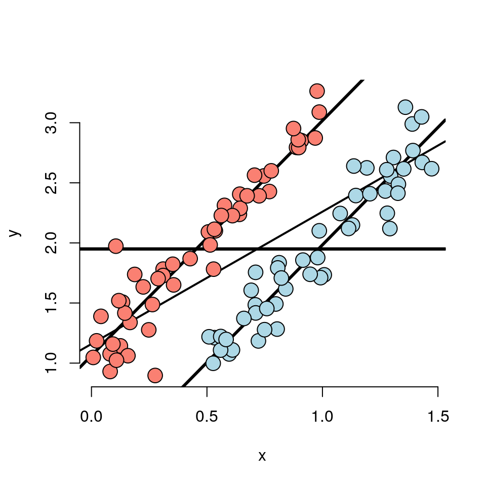

**EJEMPLO 5**

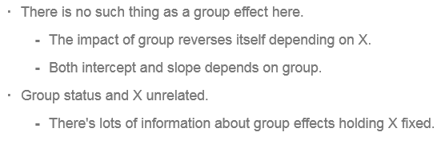

qownnotes-media-uRllAi

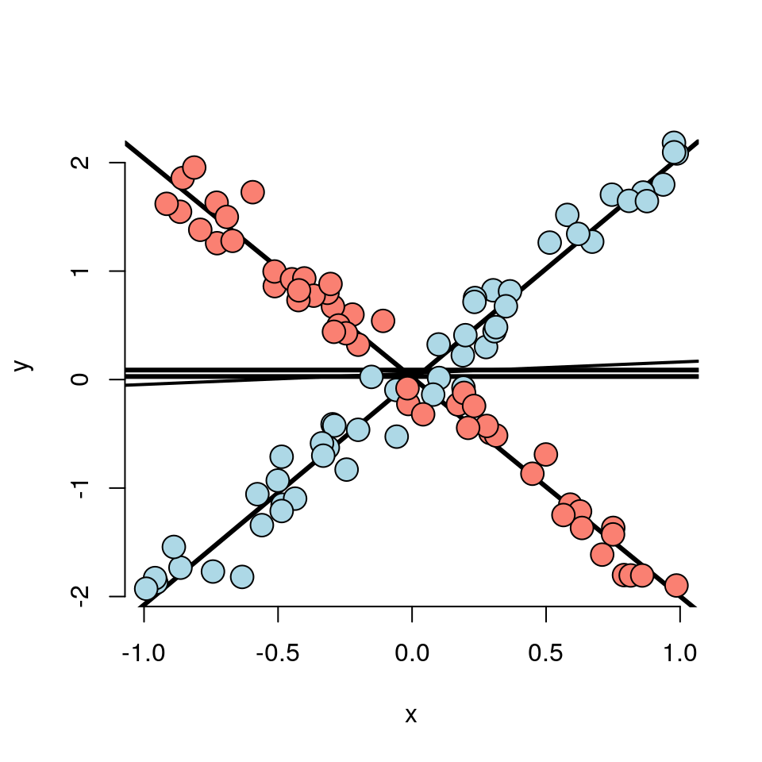

**EJEMPLO 6**

Metemos una tercera variable representada por el color

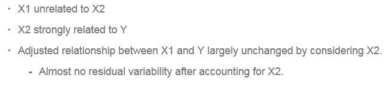

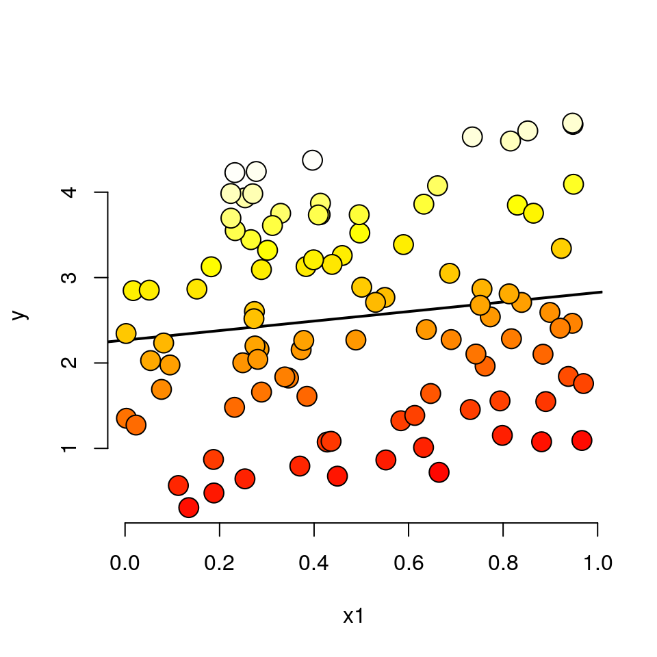

Si representáramos estos puntos en 3 dimensiones, nos daríamos cuenta que la Z forma un plano perfectamente alineado

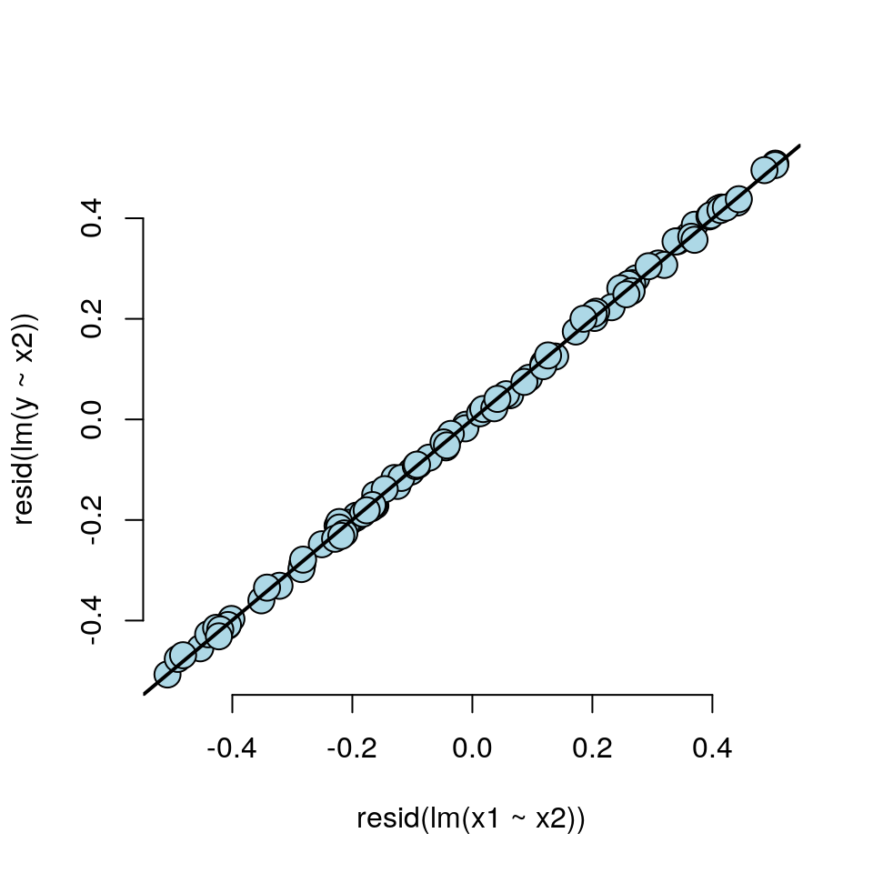